# INN Hotels Project

## Changing coefficients to odds

```python
odds = np.exp(lg.params)

# adding the odds to a dataframe
pd.DataFrame(odds, X_train1.columns, columns=["odds"]).T
```

|  | no_of_children | no_of_week_nights | required_car_parking_space | lead_time | arrival_month | arrival_date | repeated_guest | cancels | avg_price_per_room | no_of_special_requests | type_of_meal_plan_Meal Plan 2 | room_type_reserved_Room_Type 2 | market_segment_type_Corporate | market_segment_type_Offline |
| --- | --- | --- | --- | --- | --- | --- | --- | --- | --- | --- | --- | --- | --- | --- |
| odds | 1.24371 | 0.89800 | 0.20383 | 1.01616 | 0.89556 | 0.98282 | 0.04658 | 1.19992 | 1.00616 | 0.22804 | 1.45262 | 0.46018 | 0.23239 | 0.10843 |

```python
perc_change_odds = (np.exp(lg.params) - 1) * 100

# adding the change_odds% to a dataframe
pd.DataFrame(perc_change_odds, X_train1.columns, columns=["change_odds%"])
```

|  | change_odds% |
| --- | --- |
| no_of_children | 24.37057 |
| no_of_week_nights | -10.20016 |
| required_car_parking_space | -79.61738 |
| lead_time | 1.61631 |
| arrival_month | -10.44360 |
| arrival_date | -1.71765 |
| repeated_guest | -95.34161 |
| cancels | 19.99235 |
| avg_price_per_room | 0.61630 |
| no_of_special_requests | -77.19557 |
| type_of_meal_plan_Meal Plan 2 | 45.26160 |
| room_type_reserved_Room_Type 2 | -53.98193 |
| market_segment_type_Corporate | -76.76102 |
| market_segment_type_Offline | -89.15661 |

This odds view makes interpretation of the coefficients much easier. For instance, if the guest requires a parking space in their reservation, they're almost 80% less likely to cancel the reservation. If they select the meal plan type 2, they're 45% more likely to cancel the reservation.

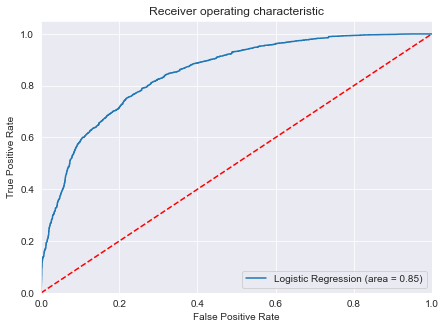

```python
logit_roc_auc_train = roc_auc_score(Y_train, lg.predict(X_train1))
fpr, tpr, thresholds = roc_curve(Y_train, lg.predict(X_train1))
plt.figure(figsize=(7, 5))
plt.plot(fpr, tpr, label="Logistic Regression (area = %0.2f)" % logit_roc_auc_train)
plt.plot([0, 1], [0, 1], "r--")
plt.xlim([0.0, 1.0])
plt.ylim([0.0, 1.05])
plt.xlabel("False Positive Rate")
plt.ylabel("True Positive Rate")
plt.title("Receiver operating characteristic")
plt.legend(loc="lower right")
plt.show()
```

```python
fpr, tpr, thresholds = roc_curve(Y_train, lg.predict(X_train1))

optimal_idx = np.argmax(tpr - fpr)
optimal_threshold_auc_roc = thresholds[optimal_idx]
print(optimal_threshold_auc_roc)
```

```
0.37567902441879497
```

```python
# Copying down the original performance summary for easier comparison

print("Training performance:")
log_reg_model_train_perf = model_performance_classification_statsmodels(lg, X_train1, Y_train)
log_reg_model_train_perf
```

```
Training performance:
```

|  | Accuracy | Recall | Precision | F1 |
| --- | --- | --- | --- | --- |
| 0 | 0.79143 | 0.63350 | 0.70368 | 0.66675 |

```python
print("Training performance using optimal auc_roc threshold:")
log_reg_model_aucroc_train_perf = model_performance_classification_statsmodels(lg, X_train1, Y_train, threshold = optimal_threshold_auc_roc)
log_reg_model_aucroc_train_perf
```

```
Training performance using optimal auc_roc threshold:
```

|  | Accuracy | Recall | Precision | F1 |
| --- | --- | --- | --- | --- |
| 0 | 0.77150 | 0.75200 | 0.62783 | 0.68433 |

While accuracy dipped by approx. 2 percentage points, using the optimal threshold from the auc_roc curve increased recall by nearly 12 percentage points. However, precision also decreased by 8 percentage points, so I'm not sure this is an objective improvement in our model. I want to use the precision recall curve to see if I can find a better threshold to use.

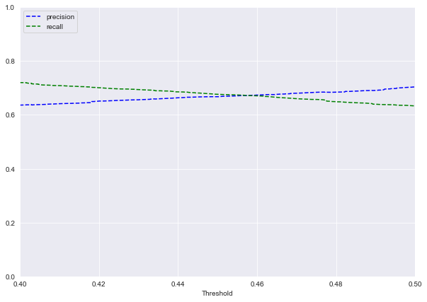

```python
y_score = lg.predict(X_train1)
prec, rec, tre = precision_recall_curve(Y_train, y_score)


def plot_prec_recall_vs_tresh(precisions, recalls, thresholds):
    plt.plot(thresholds, precisions[:-1], "b--", label="precision")
    plt.plot(thresholds, recalls[:-1], "g--", label="recall")
    plt.xlabel("Threshold")
    plt.legend(loc="upper left")
    plt.ylim([0, 1])
    plt.xlim([.4, .5])


plt.figure(figsize=(10, 7))
plot_prec_recall_vs_tresh(prec, rec, tre)
plt.show()
```

```python
optimal_threshold_prcurve = .459
```

```python
# Copying previous performance summaries for easier comparison

print("Training performance:")
log_reg_model_train_perf
```

```
Training performance:
```

|  | Accuracy | Recall | Precision | F1 |
| --- | --- | --- | --- | --- |
| 0 | 0.79143 | 0.63350 | 0.70368 | 0.66675 |

```python
print("Training performance using optimal auc_roc threshold:")
log_reg_model_aucroc_train_perf
```

```
Training performance using optimal auc_roc threshold:
```

|  | Accuracy | Recall | Precision | F1 |
| --- | --- | --- | --- | --- |
| 0 | 0.77150 | 0.75200 | 0.62783 | 0.68433 |

```python
print("Training performance using optimal precision/recall threshold:")
log_reg_model_prec_rec_train_perf = model_performance_classification_statsmodels(lg, X_train1, Y_train, threshold = optimal_threshold_prcurve)
log_reg_model_prec_rec_train_perf
```

```
Training performance using optimal precision/recall threshold:
```

|  | Accuracy | Recall | Precision | F1 |
| --- | --- | --- | --- | --- |
| 0 | 0.78434 | 0.67141 | 0.67302 | 0.67221 |